# Ecological forecasting in R

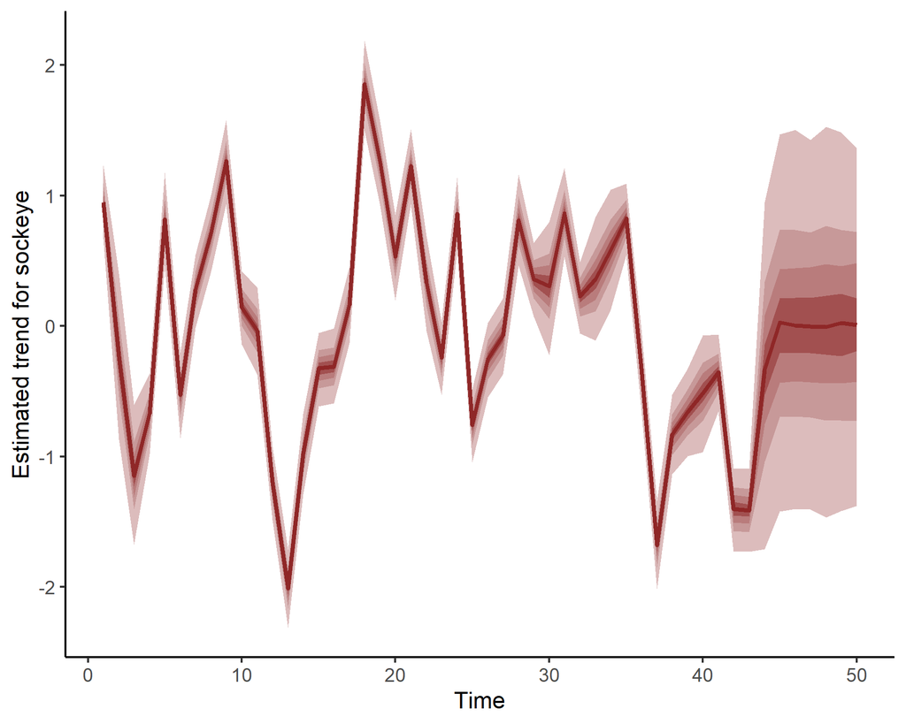

```r
plot(
  model4,
  type = 'trend'
)
```

```
## No non-missing values in test_observations; cannot calculate forecast score
```

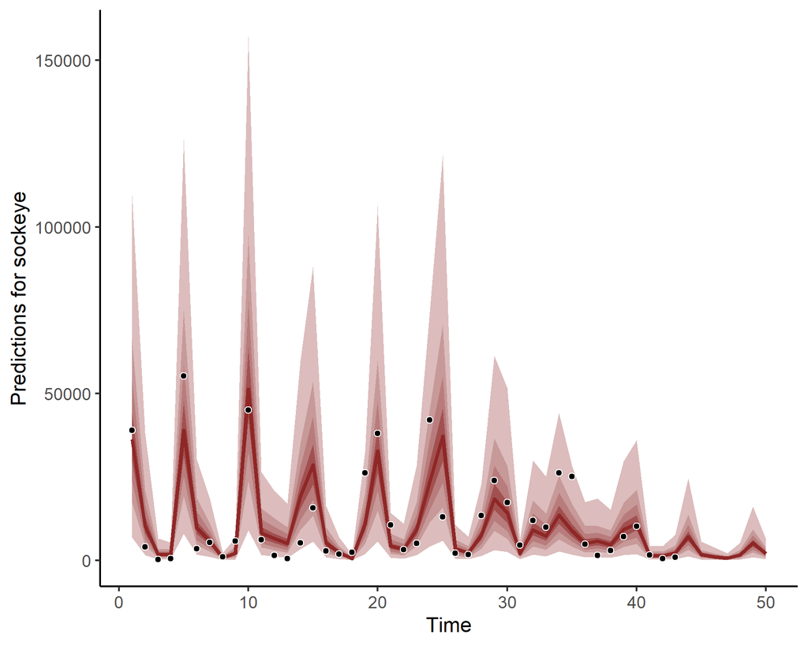

```r
plot(
  hindcast(model3)
)
```

```
## No non-missing values in test_observations; cannot calculate forecast score
```

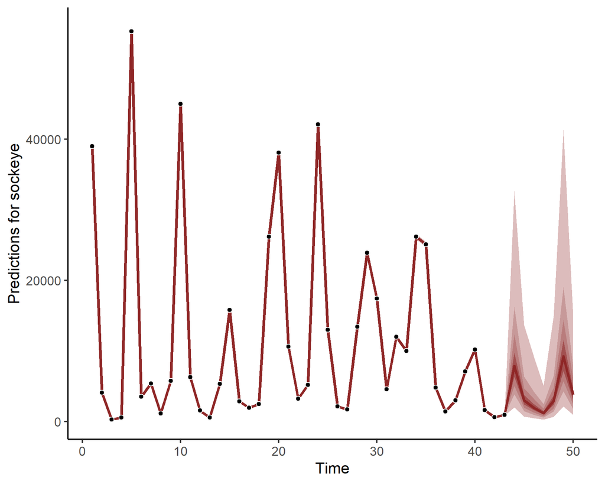

```r
plot(
  hindcast(model4)
)
```

### Approximate Leave-One-Out CV

Here the extreme flexibility of the AR1 trend is apparent in the hindcasts for `model4`. Hopefully this gives you more of an idea about why we can’t put too much faith in residual or fitted value diagnostics for these flexible dynamic models. Ok so we cannot use in-sample fits or residual diagnostics to guide reasonable comparisons of these two models. It would be more appropriate to use 1-step ahead residuals for interrogation. But computing these is extremely computationally demanding. How then can we compare models? Using `loo_compare()`, we can ask which model would likely give better predictions for new data *within the training set*. This method of approximating leave-one-out prediction error (using a method called Pareto Smoothed Importance Sampling (PSIS)) is widely-used for comparing Bayesian models, and is generally interpreted in the same way that AIC comparisons can be interpreted:

```r
loo_compare(
  model3,
  model4
)
```

```
## Warning: Some Pareto k diagnostic values are too high. See help('pareto-k-diagnostic') for details.
## Warning: Some Pareto k diagnostic values are too high. See help('pareto-k-diagnostic') for details.
```

```
##        elpd_diff se_diff
## model3       0.0       0.0
## model4 -443317.4   68161.1
```

The Piecewise / Negative Binomial model is strongly favoured here, yielding much higher values of the [Expected Log Predictive Density (ELPD; also known as the log score)](https://link.springer.com/article/10.1007/s11222-016-9696-4). This is one useful metric for choosing among models, but it has a few downfalls. First, it is challenging to use PSIS-LOO for time series models, particularly those that have flexible autoregressive latent processes (like `model4` has above). These autoregressive processes can fit the training data very well, but when we ask how they would generalize to new data within the training period they can give poor predictions because they don’t have any past state values to learn from. This is one reason why `loo()` very often gives warnings for these models. **My recommendation would be to only use `loo()` and `loo_compare()` when comparing models that have different types of covariate effects, but that do not have different types of dynamic trends**. Once you’ve selected your covariate model, then you can add an appropriate trend if needed. Alternatively, you could instead compare them solely on their abilities to predict *future* out-of-sample data. This is where leave-future-out cross-validation may be handy.

### Approximate Leave-Future-Out CV

`mvgam` includes functions that facilitate leave-future-out comparisons. Time series models are often evaluated using an expanding window training technique, where the model is initially trained on some subset of data from $t = 1$ to $t = n_{train}$, and then is used to produce forecasts for the next $h$ time steps $(t = n_{train} + h)$. In the next iteration, the size of training data is expanded by a single time point and the process repeated. This is obviously computationally challenging for Bayesian time series models, as the number of refits can be very large. `mvgam` uses an approximation based on importance sampling. Briefly, we refit the model using the first $min_t$ observations to perform a single exact $h~ahead$ forecast step. This forecast is evaluated against the $min_t + h$ out of sample observations using the ELPD as with the LOO comparisons above. Next, we approximate each successive round of expanding window forecasts by moving forward one step at a time $for~i~in~1:N_{evaluations}$ and re-weighting draws from the model’s posterior predictive distribution using PSIS. In each iteration $i$, PSIS weights are obtained for all observations that would have been included in the model if we had re-fit. If these importance ratios are stable, we consider the approximation adequate and use the re-weighted posterior’s forecast for evaluating the next holdout set of testing observations $((min_t + i + 1):(min_t + i + h))$. This is similar to the process of particle filtering to update forecasts in light of new data by re-weighting the posterior draws using importance weights. But at some point the importance ratio variability will become too large and importance sampling will be unreliable. This is indicated by the estimated shape parameter k of the generalized Pareto distribution crossing a certain threshold `pareto_k_threshold`. Only then do we refit the model using all of the observations up to the time of the failure. We then restart the process and iterate forward until the next refit is triggered. The process, which is implemented using the `lfo_cv()` function, is computationally much more efficient, as only a fraction of the evaluations typically requires refits (the algorithm is described in detail by [Bürkner et al. 2020](https://www.tandfonline.com/doi/full/10.1080/00949655.2020.1783262)).

Run the approximator for the first model, setting `min_t = 20` and using a forecast horizon of `fc_horizon = 2`

```r
lfo_pw <- lfo_cv(
  model3,
  min_t = 20,
  fc_horizon = 2,
  n_cores = 4
)
```

The `S3` plotting function for these `lfo_cv` objects will show the Pareto-k values and ELPD values over the evaluation time points. For the Pareto k plot, a dashed red line indicates the specified threshold chosen for triggering model refits. For the ELPD plot, a dashed red line indicates the bottom 10% quantile of ELPD values. Points below this threshold may represent outliers that were more difficult to forecast

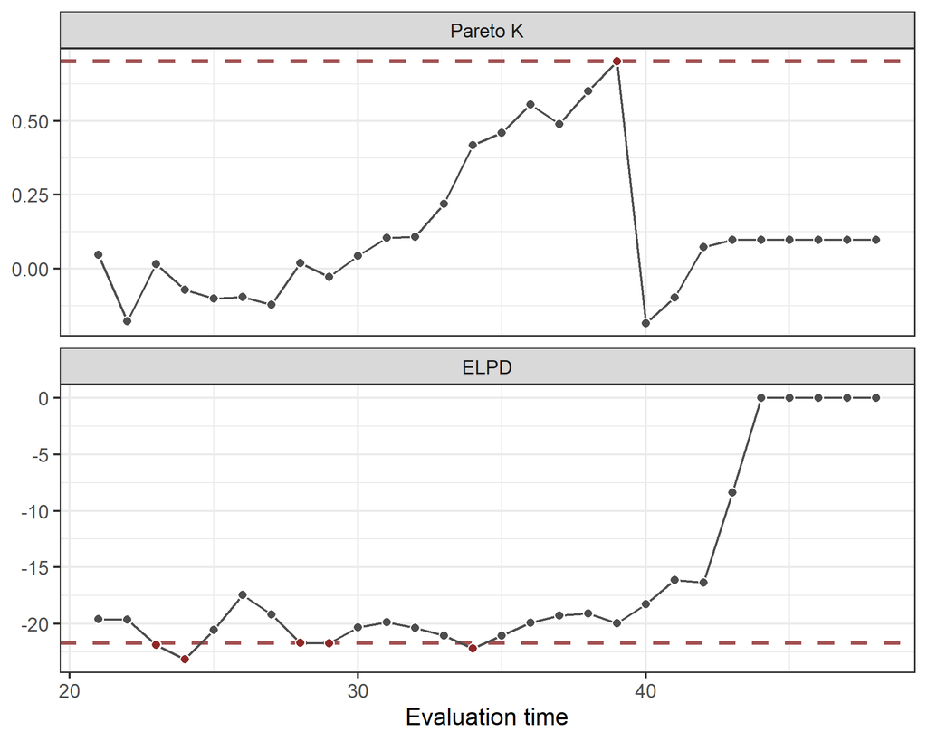

```r
plot(lfo_pw)
```

The top plot (the Pareto k plot) indicates that we only needed one additional refit to give good approximate predictions for the Piecewise / Negative Binomial model

```r
lfo_ar <- lfo_cv(
  model4,
  min_t = 20,
  fc_horizon = 2,
  n_cores = 4
)
```

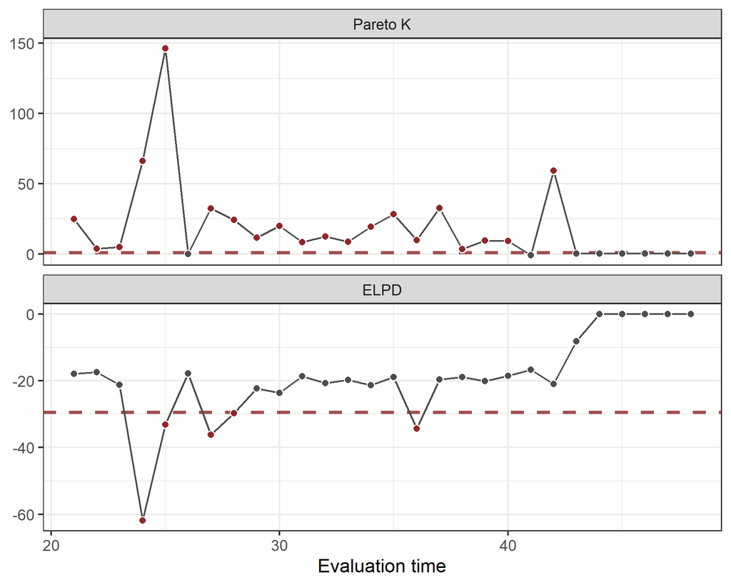

```r
plot(lfo_ar)
```

The Poisson / AR model, in contrast, needed to be refit many times to ensure the stability of importance-weighted predictions. We would generally expect more refits for this model as the underlying trend has less “memory” than the piecewise trend, so its forecasts could become irrelevant more quickly as a result.

Compare ELPDs for the two models using all nonmissing evaluation timepoints by plotting the differences in their scores. This plot will give us an indication if one model is consistently giving better h-step ahead forecasts when trained on successively more data

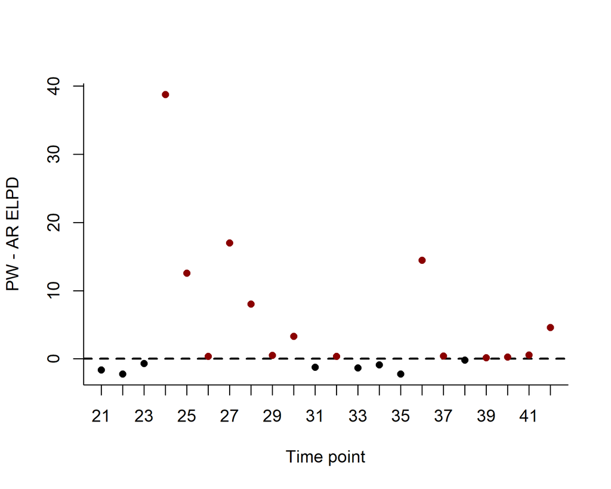

```r
# determine which timepoints were not missing in the evaluation set
nonmiss_evalpoints <- which(
  !is.na(model_data$recruits[22:NROW(model_data)])
)

# plot the PW ELPD values minus the AR ELPD values
# values will be > 0 if the PW model gave better predictions
# (ELPD is better when larger)
pw_minus_ar <- lfo_pw$elpds[nonmiss_evalpoints] -
  lfo_ar$elpds[nonmiss_evalpoints]
plot(
  pw_minus_ar,
  ylab = 'PW - AR ELPD',
  xlab = 'Time point',
  pch = 16,
  bty = 'l',
  cex = 1,
  col = 'white',
  xaxt = 'n'
)
axis(
  side = 1,
  at = nonmiss_evalpoints,
  labels = lfo_pw$eval_timepoints[nonmiss_evalpoints]
)
abline(
  h = 0,
  lty = 'dashed',
  lwd = 2
)

# show all ELPD comparisons in black
points(
  pw_minus_ar,
  pch = 16,
  cex = 0.95
)

# highlight the comparisons for when the PW predictions were better
points(
  ifelse(pw_minus_ar > 0, pw_minus_ar, NA),
  pch = 16,
  cex = 0.95,
  col = 'darkred'
)
```

The Piecewise / Negative Binomial model tends to give better probabilistic predictions throughout the leave-future-out exercise. This result agrees with results from the in-sample comparison using `loo()` above. But overall, I would tend to favour the out-of-sample metrics more when performing model selection, especially given that we are working with a time series here.